# Landmark Registration

Michele Gubian

# f0 contours and (syllable) boundaries

## f0 contours and (syllable) boundaries

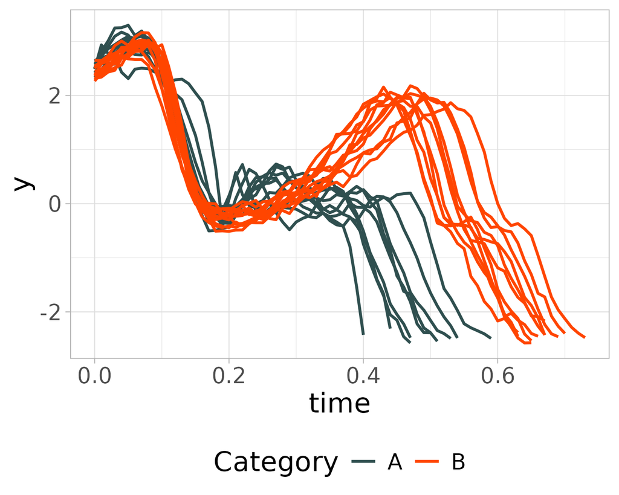

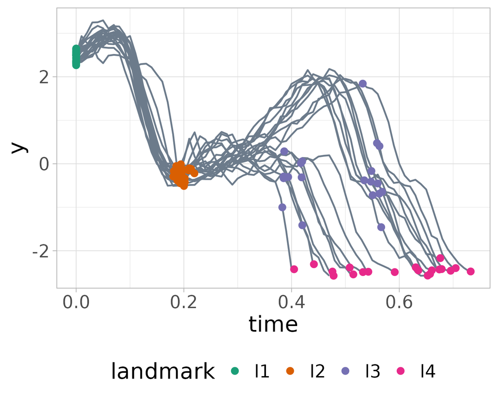

## f0 contours and (syllable) boundaries

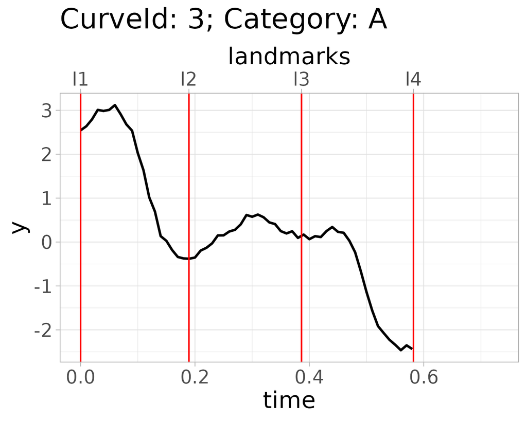

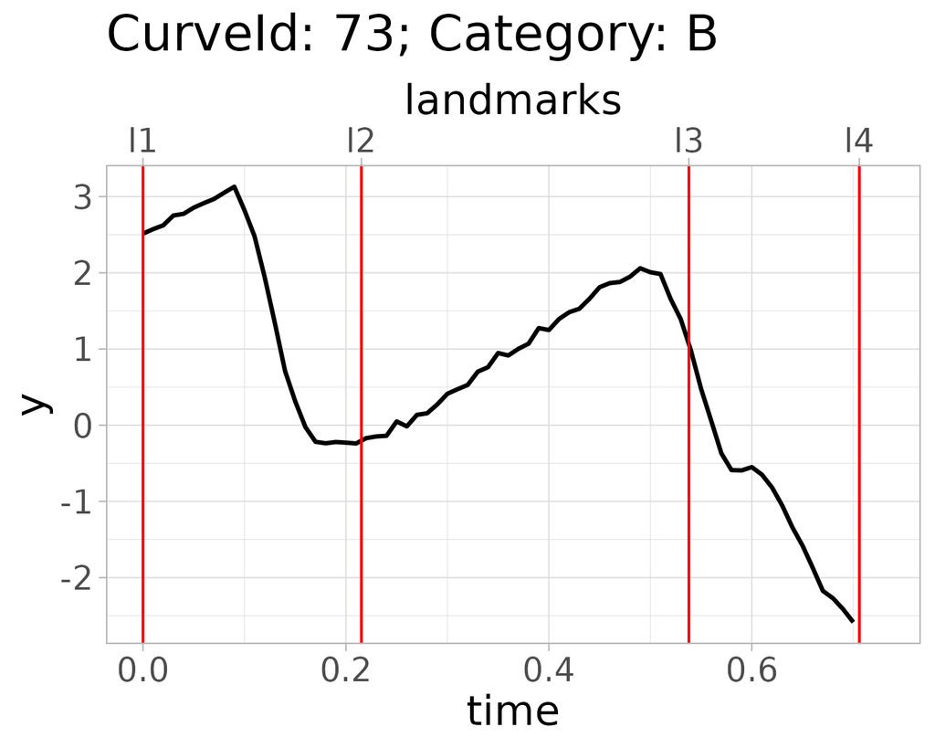

## Modelling misaligned contours

- Anchor across-curves variation to meaningful boundaries (landmarks)
- Separate variation due to:
  1. boundary misalignment
  2. shape variation anchored to boundaries
- Boundaries may be intrinsic, e.g. peaks
- or extrinsic, e.g. syllable boundaries on a f0 contour
- Analyse both sources of variation jointly

## Predicted curves and boundary positions

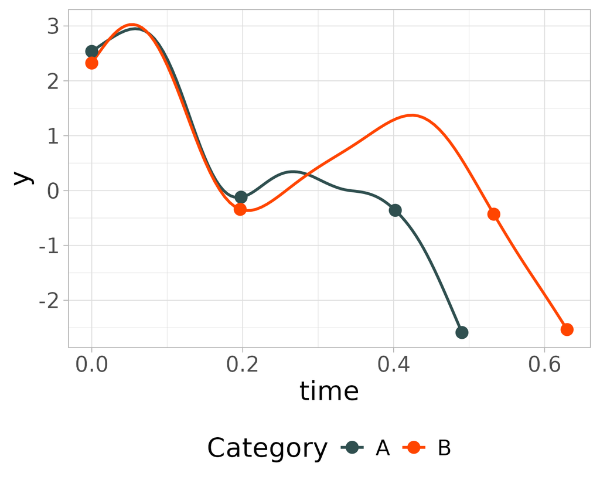

## Predicted curves and durations

Time-aligned curves

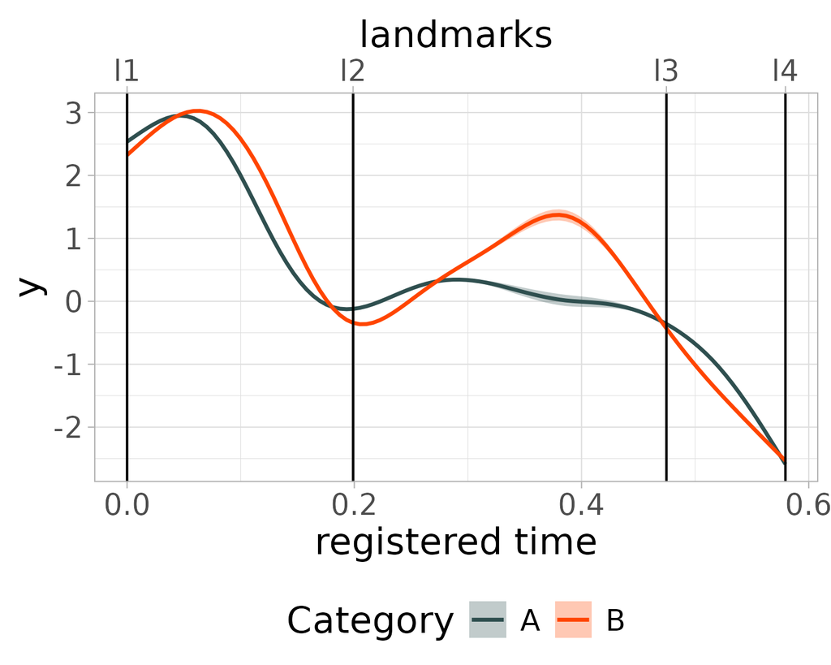

Interval durations

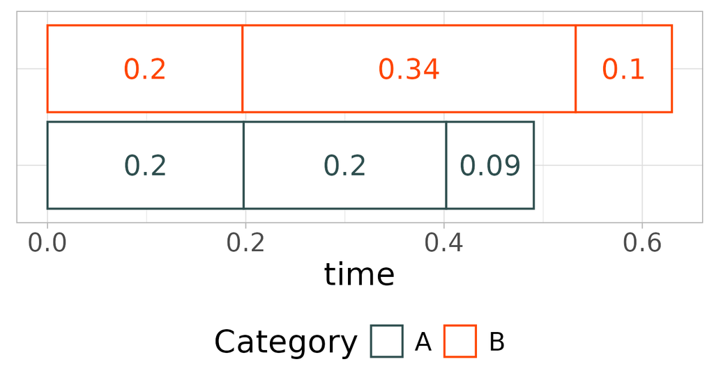

## f0 contours and (syllable) boundaries

## General strategy

1. Pre-process contours’ time axis
2. Apply FPCA + L(ME)R + Reconstruction

## Four approaches to time axis pre-processing

1. Original time axis (i.e. do nothing)
2. Linear time normalisation
3. Landmark registration
4. Landmark registration + time warping curves

# 1. Original time axis

## Apply FPCA

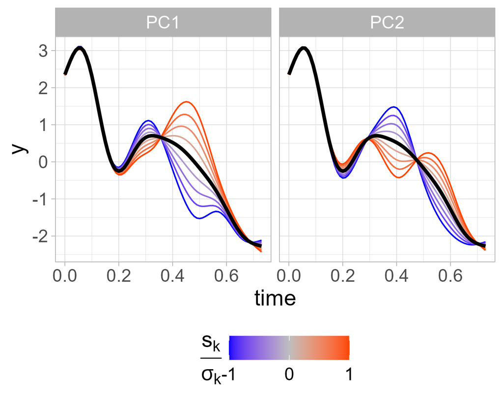

## PC scores vs. Category

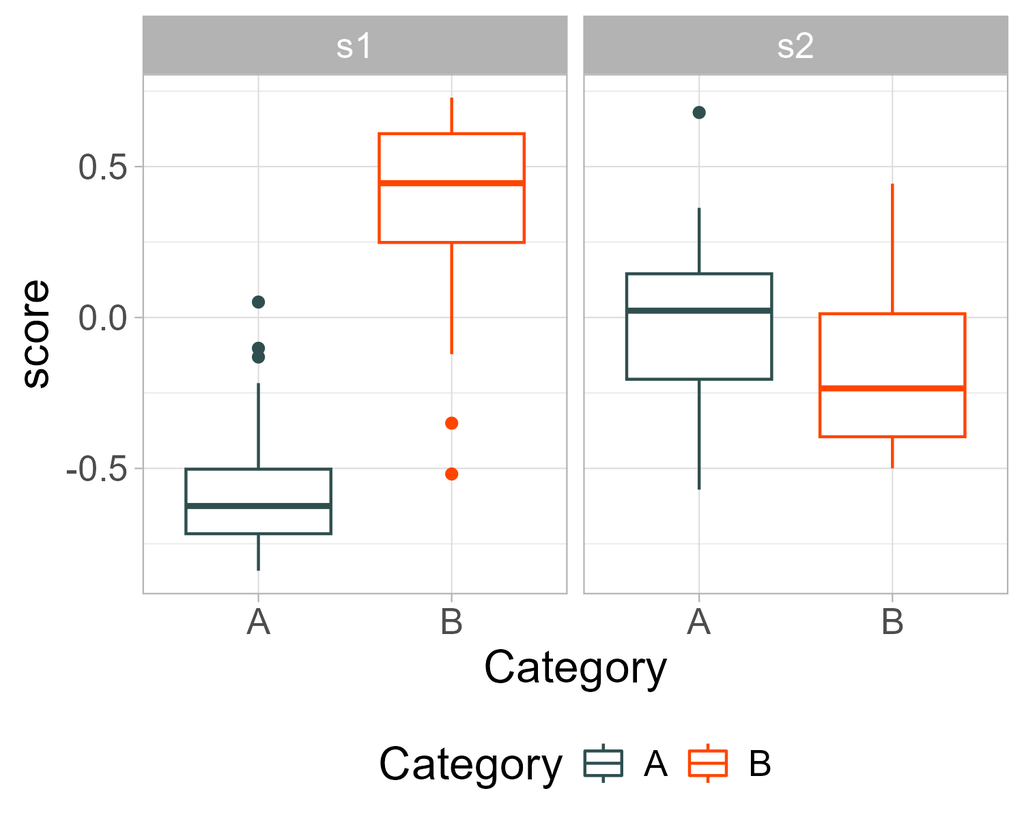

## Fit a regression model on s<sub>1</sub>

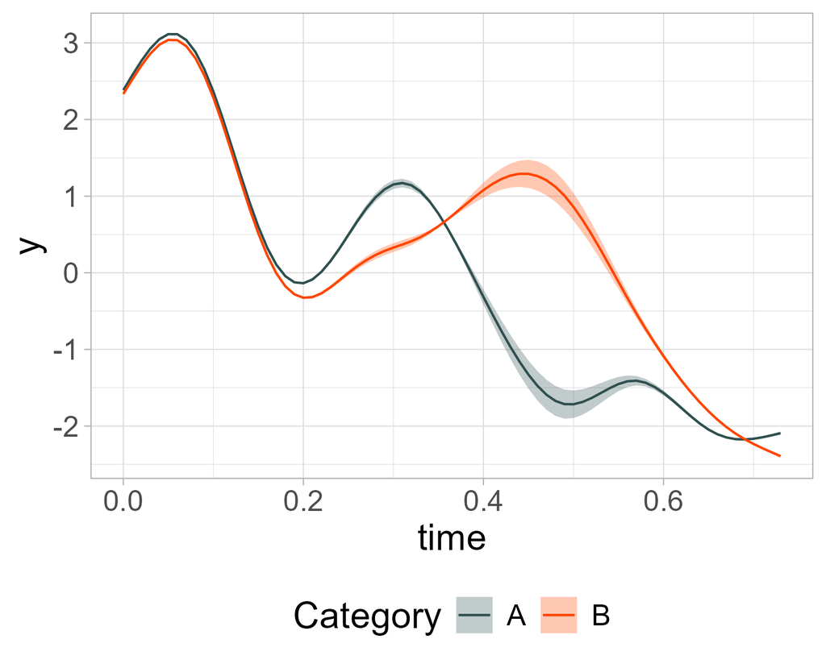

## Comments

- Predicted curves do not show duration variation
- Landmarks are missing

# 2. Linear time normalisation

## Linear time normalisation

After

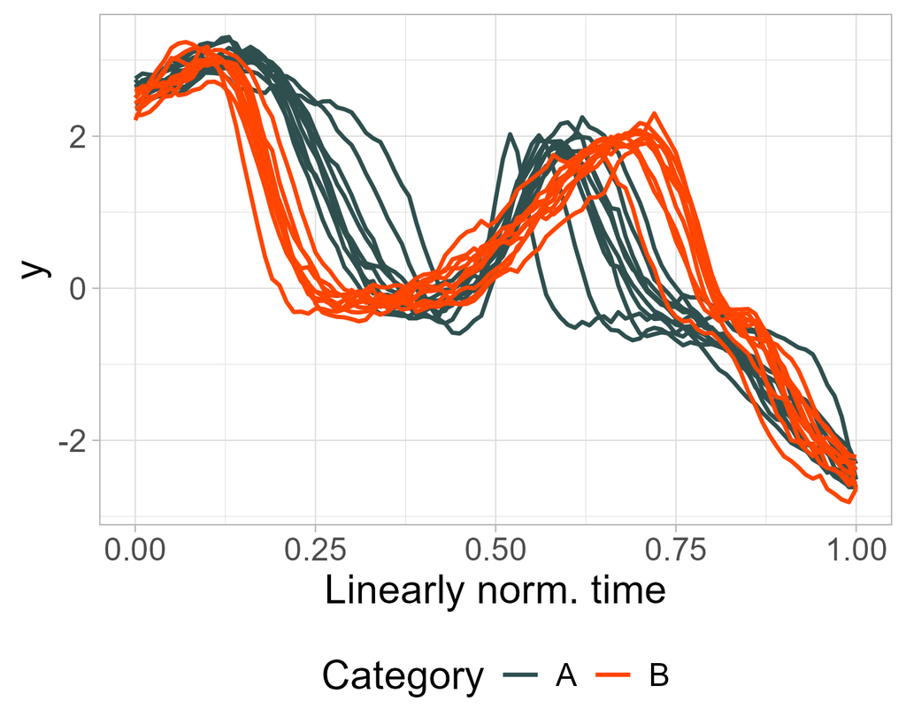

## Linear time normalisation

After

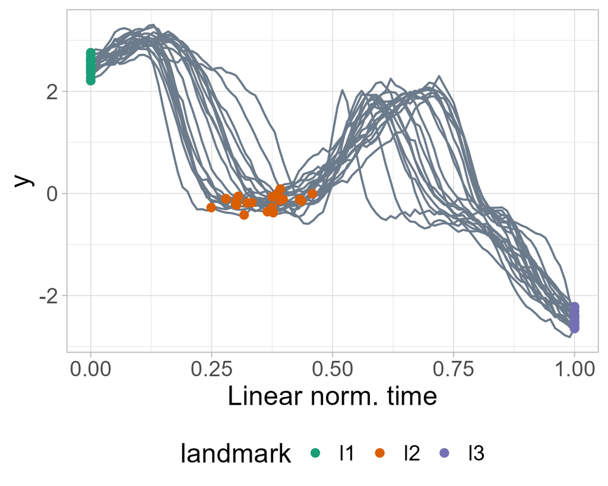

## Apply FPCA to linearly time-normalised curves

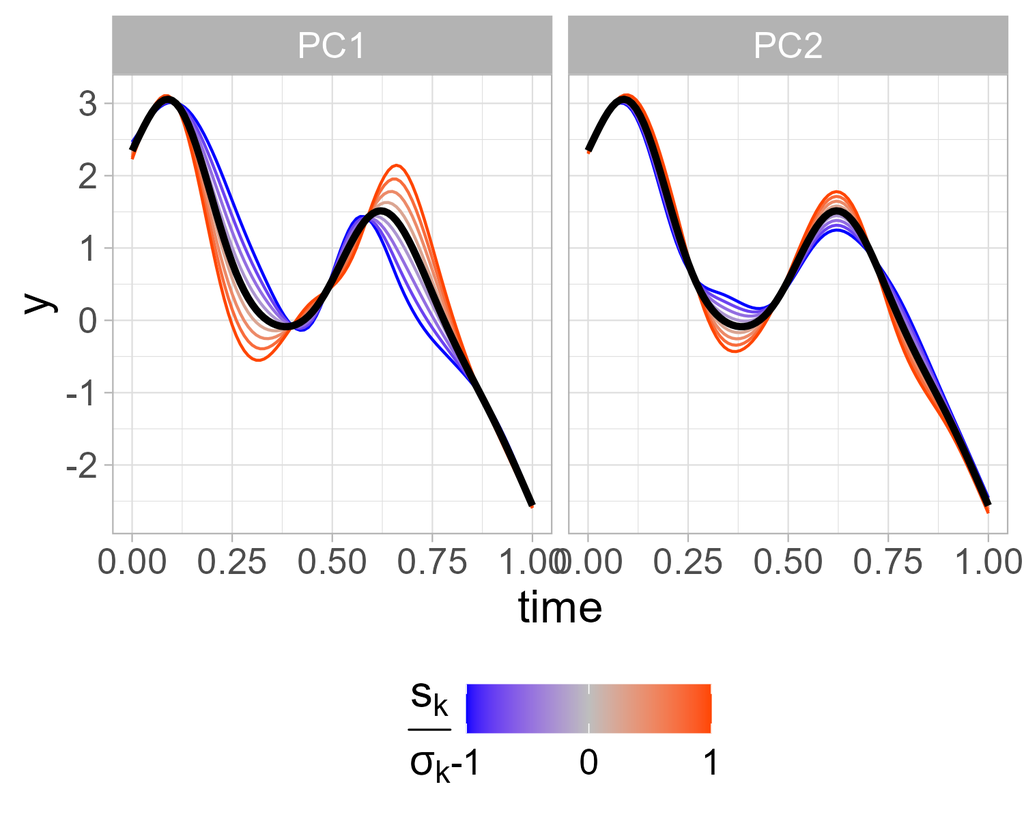

## PC scores vs. Category

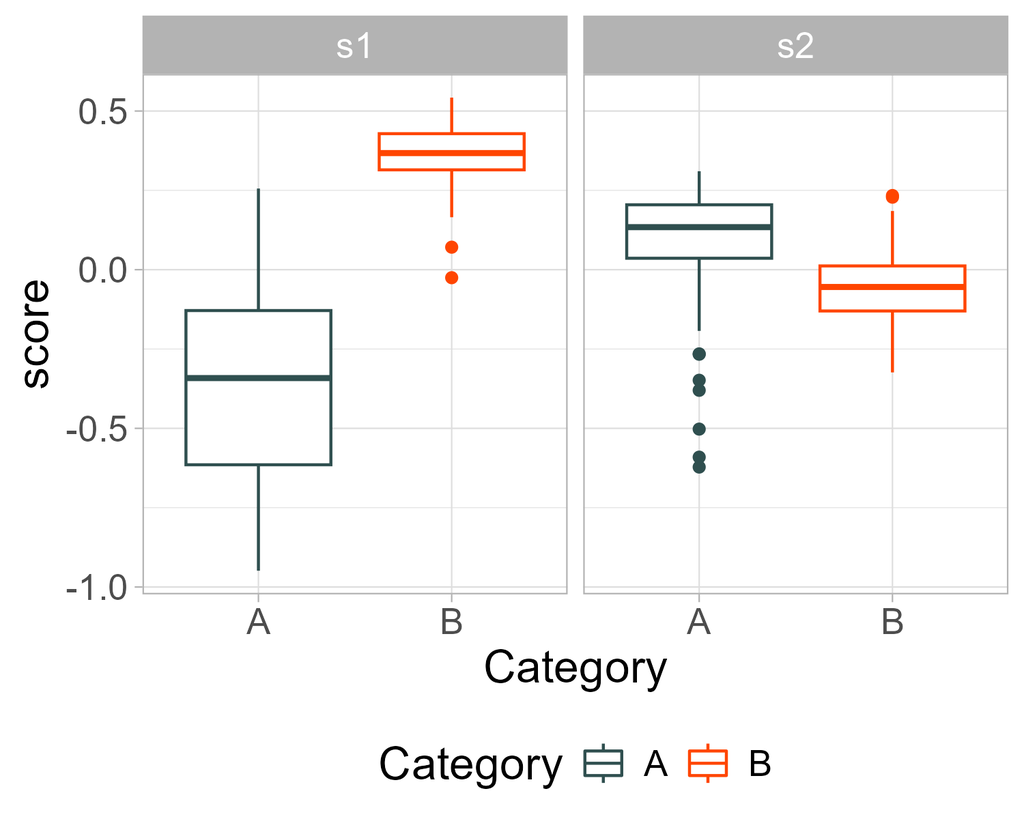

## Fit a regression model on s<sub>1</sub>

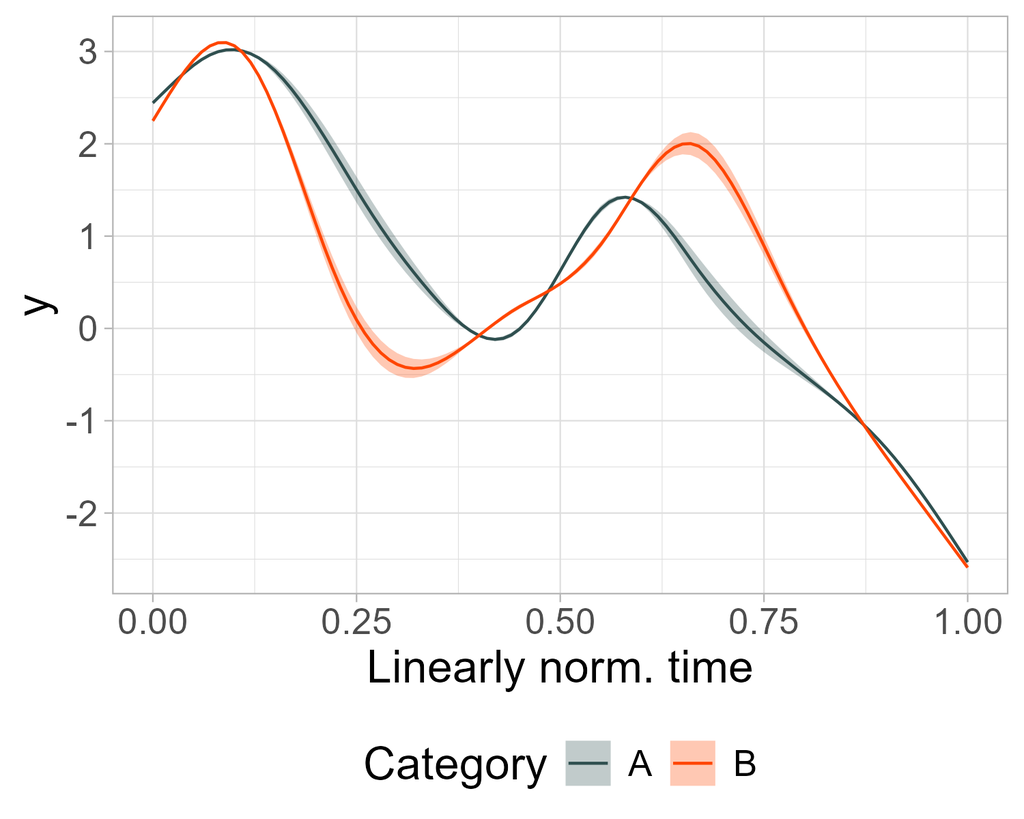

## Comments

- Curve shape distorted
- Predicted curves do not show duration variation
- Landmarks are missing

# 3. Landmark registration

## Landmark registration

After

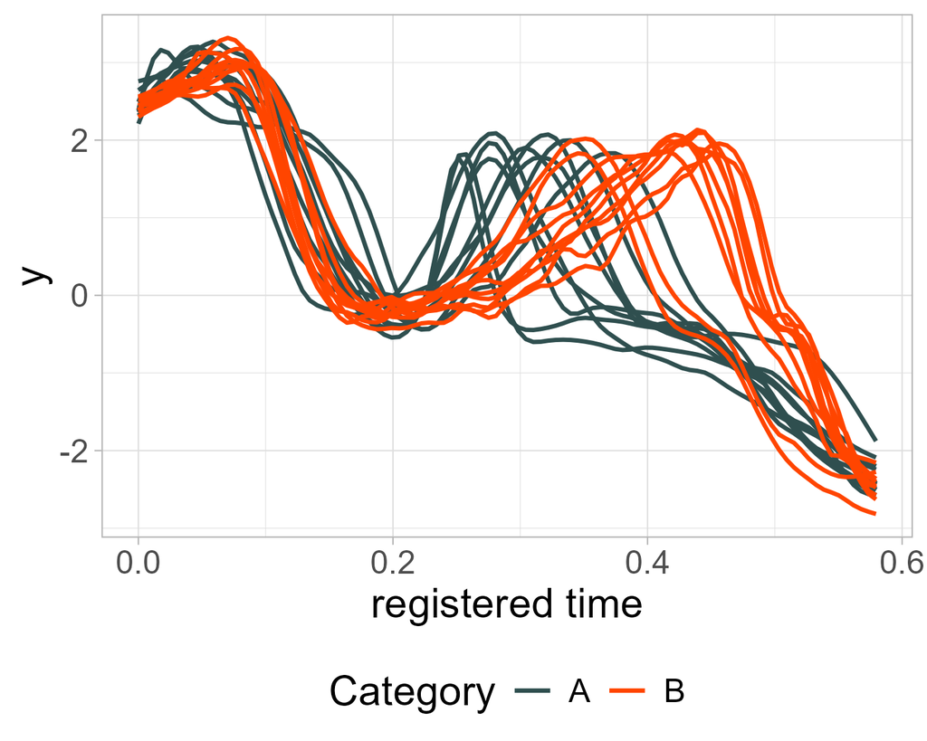

## Landmark registration

After

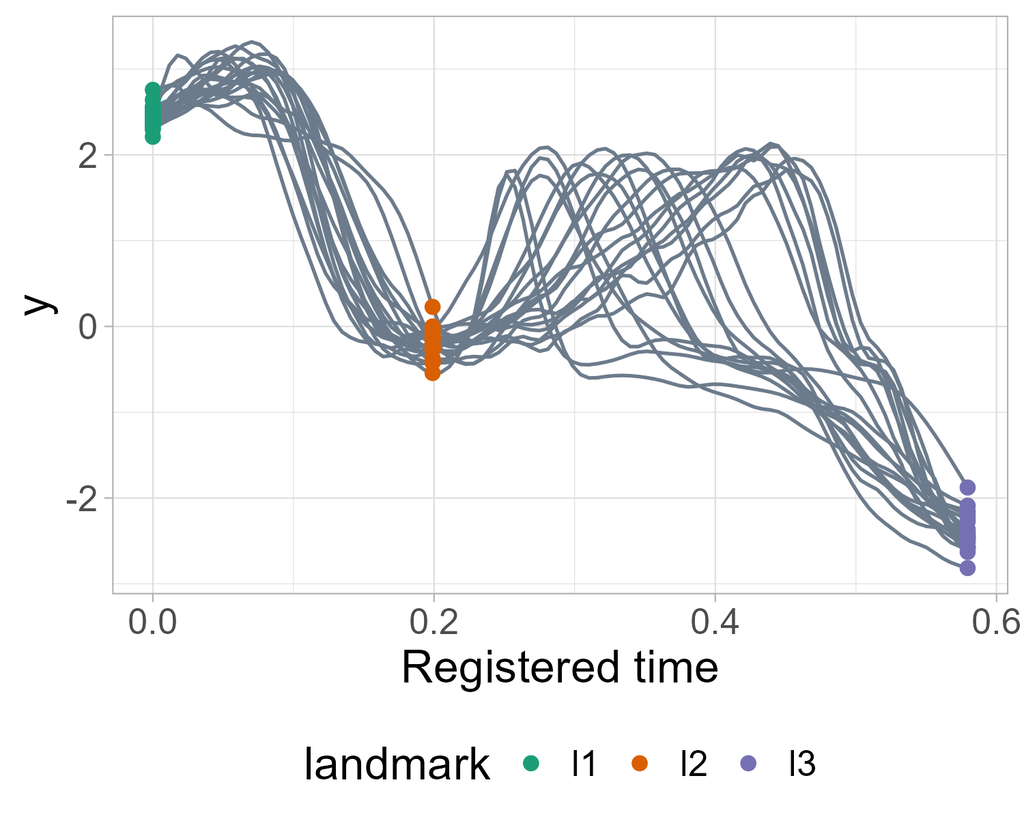

## Landmark registration

- Aligns all curves to the given landmarks
- Curves are smoothly distorted
- Depends on landmarks given by the user
- Does not align curves based on their shapes (like DTW)

## Procedure overview

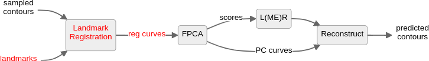

## Apply FPCA to landmark-registered curves

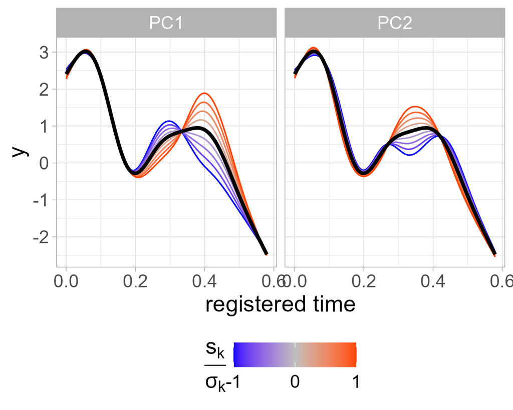

## PC scores vs. Category

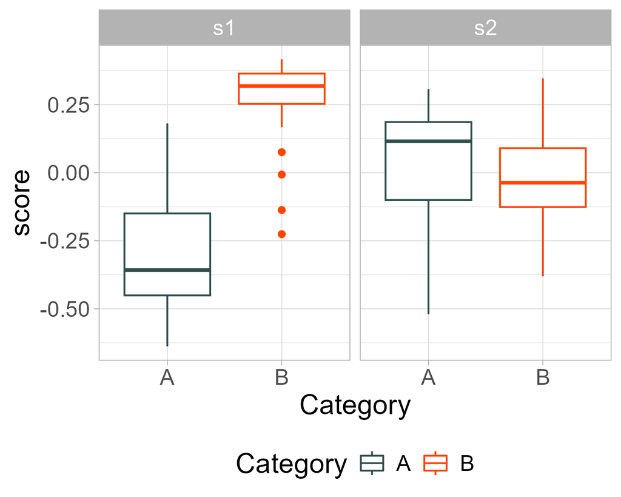

## Fit a regression model on s<sub>1</sub>

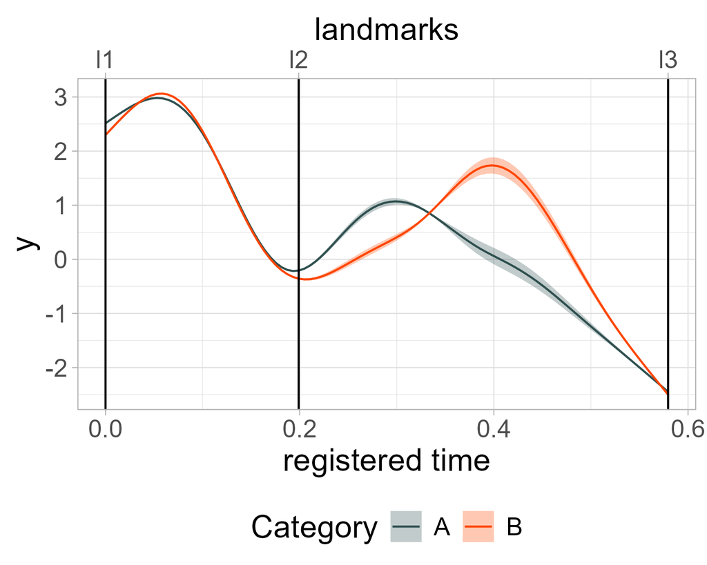

## Comments

- Curve shape distorted
- Predicted curves do not show duration variation
- Landmarks are preserved
  - we know where they are
  - we interpret curve shapes against landmark position

# Landmark registration + time warping curves

## Time warping curves as log rates

$- log \frac{dh(t)}{dt}$

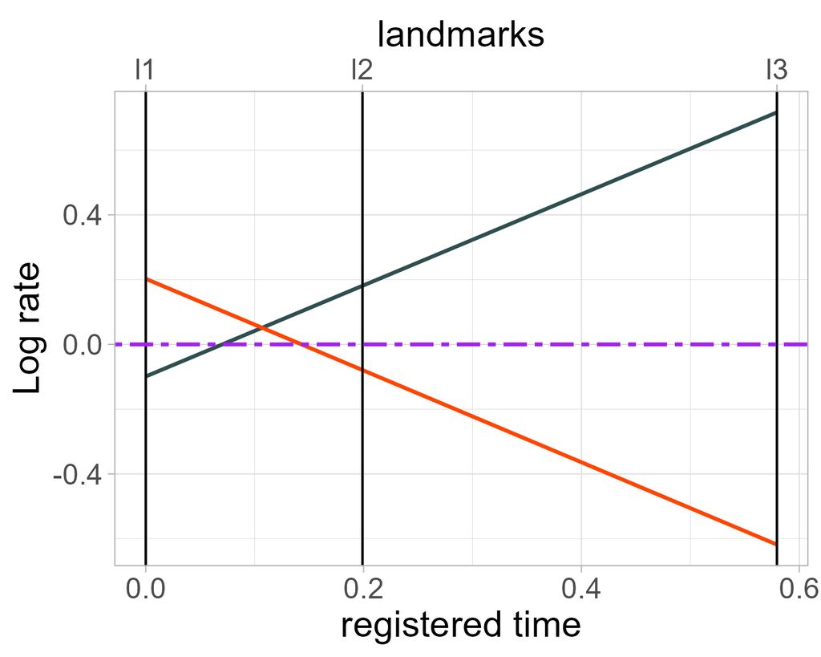

## Procedure

- Compute landmark registration
- Pull out time warping curves $h(t)$
- Transform them into log rates $r(t) = - log \frac{dh(t)}{dt}$
- Compose 2-dimensional curves from
  1. Landmark registered curves
  2. Respective log rates
- Apply multidimensional FPCA
- Apply linear regression on a PC score
- Reverse log rate predicted curves to inter-landmark durations

## Procedure overview (1)

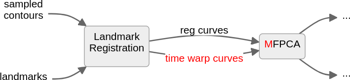

## Procedure overview (2)

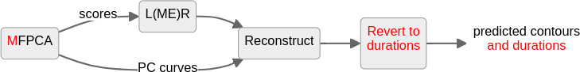

## Apply 2-dim FPCA to curves + log rates

Curve dimension

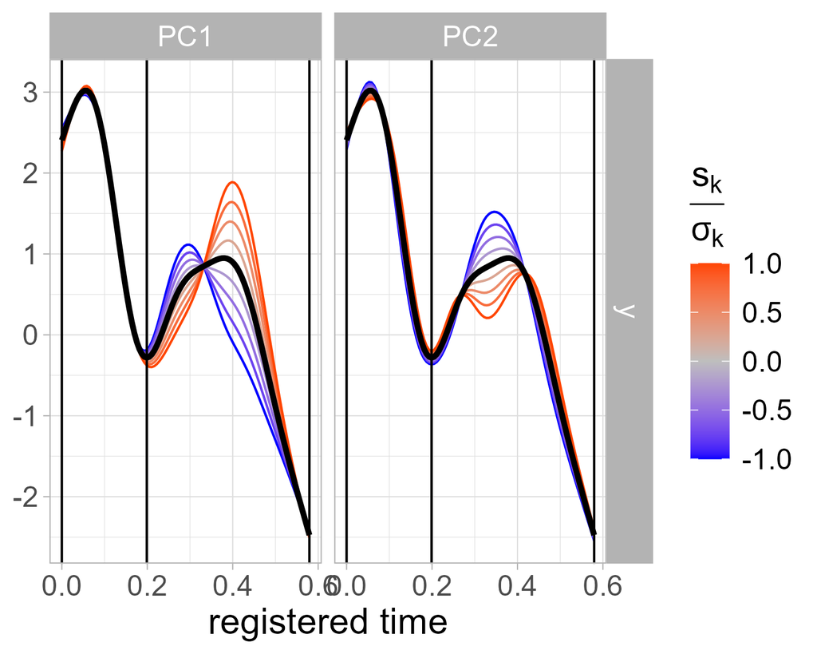

Log rate dimension

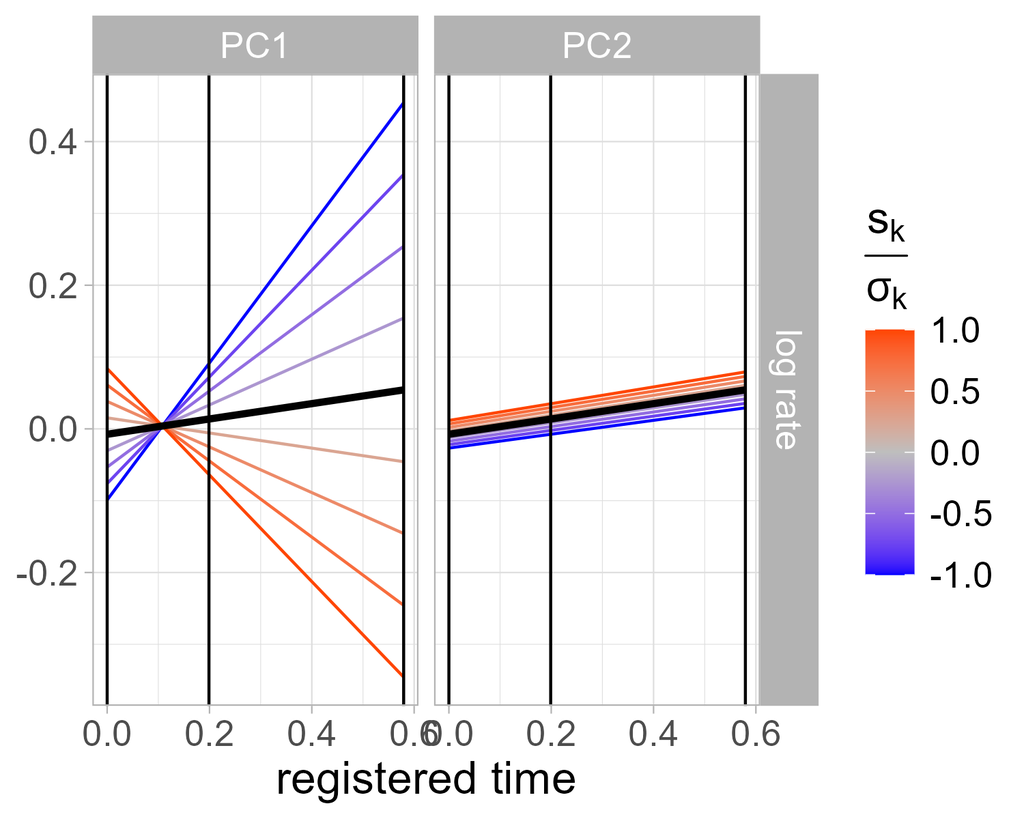

## Apply 2-dim FPCA to curves + log rates

Curve dimension

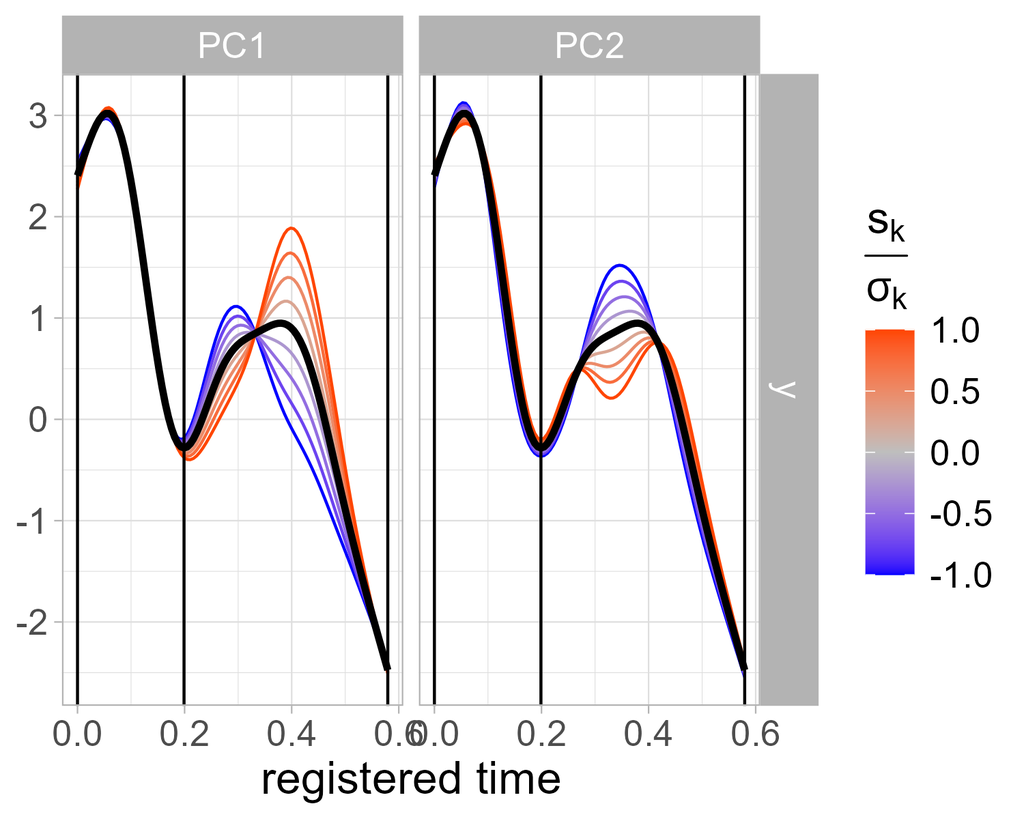

Duration dimension

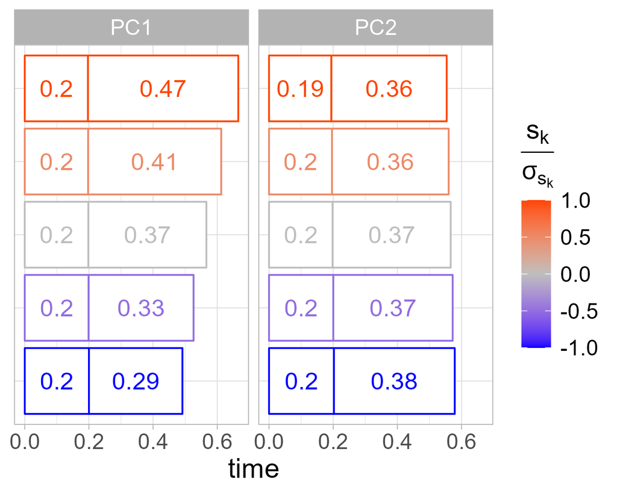

## Apply 2-dim FPCA to curves + log rates

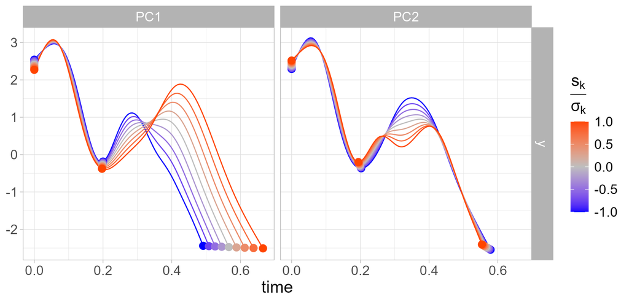

## PC scores vs. Category

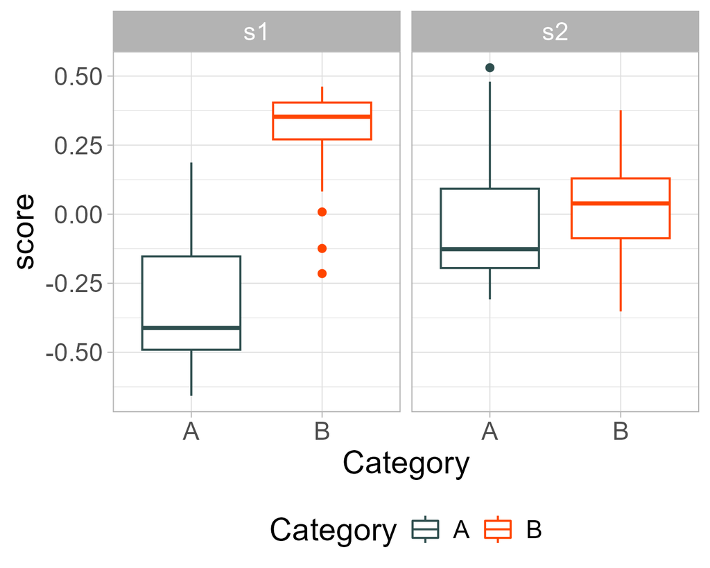

## Fit a regression model on s<sub>1</sub>

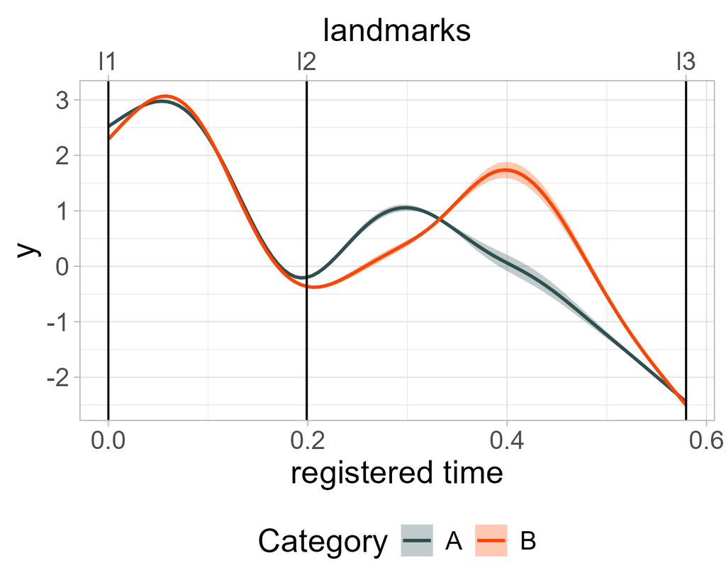

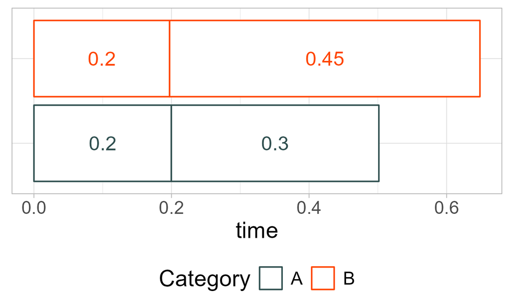